# homework2

0556078

October 19, 2016

#### Question 1:

```r
url <- "http://ghuang.stat.nctu.edu.tw/course/statmethods16/files/data/femaleControlsPopulation.csv"
filename <- basename(url)
download.file(url, destfile=filename)
x <- unlist( read.csv(filename) )
```

1.a Ans: 23.8934

```r
round(mean(x),4)
```

```
## [1] 23.8934
```

1.b Ans: 0.2706

```r
set.seed(1)
round(abs(mean(sample(x, 5)) - mean(x)), 4)
```

```
## [1] 0.2706
```

1.c Ans: 1.4334

```r
set.seed(5)
round(abs(mean(sample(x, 5)) - mean(x)), 4)
```

```
## [1] 1.4334
```

1.d Ans: C)Because the average of the samples is a random variable.

1.e Ans: 49.8%

```r
set.seed(1)
smp <- c()
for(i in c(1:1000)){
  smp <- c(smp,mean(sample(x, 5)))
}
mean((smp-mean(x)) > 1 | (smp-mean(x)) < -1)
```

```
## [1] 0.498
```

1.f Ans: 49.76%

```r
set.seed(1)
smp <- c()
for(i in c(1:10000)){
  smp <- c(smp,mean(sample(x, 5)))
}
mean((smp-mean(x)) > 1 | (smp-mean(x)) < -1)
```

```
## [1] 0.4976
```

1.g Ans: 1.1%

```r
set.seed(1)
smp <- c()
for(i in c(1:1000)){
  smp <- c(smp,mean(sample(x, 50)))
}
mean((smp-mean(x))>1)
```

```
## [1] 0.011
```

1.h Ans: B)They both look roughly normal, but with a sample size of 50 the spread is smaller.

1.i Ans: 97.6%

```r
mean(smp>=23 & smp<=25)
```

```
## [1] 0.976
```

1.j Ans: 97.66%

```r
round(pnorm(25,mean=23.9,sd=0.43) - pnorm(23,mean=23.9,sd=0.43), 4)
```

```
## [1] 0.9766
```

#### Question 2:

```r
url <- "http://ghuang.stat.nctu.edu.tw/course/statmethods16/files/data/mice_pheno.csv"
filename <- basename(url)
download.file(url, destfile=filename)
dat <- na.omit( read.csv(filename) )
```

2.a Ans: 68.27%

```r
round(pnorm(1) - pnorm(-1), 4)
```

```
## [1] 0.6827
```

2.b Ans: 95.45%

```r
round(pnorm(2) - pnorm(-2), 4)
```

```
## [1] 0.9545
```

2.c Ans: 99.73%

```r
round(pnorm(3) - pnorm(-3), 4)
```

```
## [1] 0.9973
```

2.d Ans: 69.51%

```r
library(rafalib)
y <- dat$Bodyweight[dat$Diet == "chow" & dat$Sex == "M"]
u_y <- mean(y)
var_y <- popvar(y) # equal to mean((y-mean(y))^2)
sd_y <- popsd(y)   # equal to sqrt(popvar(y))
round(mean(y>u_y-sd_y & y<u_y+sd_y), 4)
```

```
## [1] 0.6951
```

2.e Ans: 94.62%

```r
round(mean(y>u_y-2*sd_y & y<u_y+2*sd_y), 4)
```

```
## [1] 0.9462
```

2.f Ans: 99.1%

```r
round(mean(y>u_y-3*sd_y & y<u_y+3*sd_y), 4)
```

```
## [1] 0.991
```

2.g Ans: C) The mouse weights are well approximated by the normal distribution, although the larger values (right tail) are larger than predicted by the normal. This is consistent with the differences seen between question c and f.

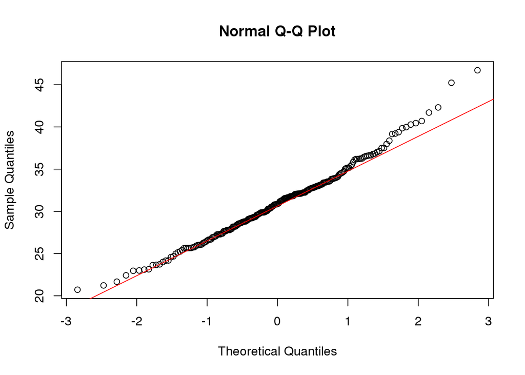

```r
qqnorm(y)
qqline(y, col=2)
```

2.h Ans: B)This just happens to be how nature behaves. Perhaps the result of many biological factors averaging out.

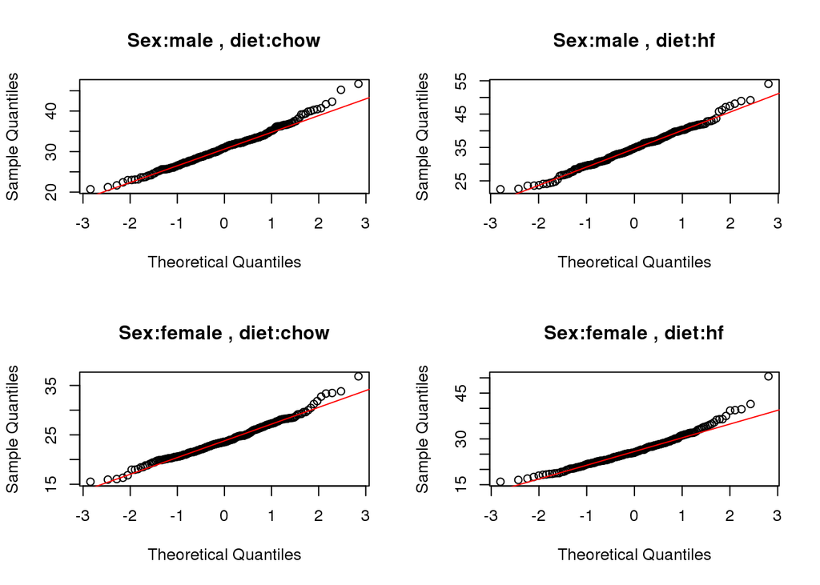

```r
par(mfrow = c(2, 2))
y <- dat$Bodyweight[dat$Diet == "chow" & dat$Sex == "M"]
qqnorm(y, main = "Sex:male , diet:chow");qqline(y, col=2)
y <- dat$Bodyweight[dat$Diet == "hf" & dat$Sex == "M"]
qqnorm(y, main = "Sex:male , diet:hf");qqline(y, col=2)
y <- dat$Bodyweight[dat$Diet == "chow" & dat$Sex == "F"]
qqnorm(y, main = "Sex:female , diet:chow");qqline(y, col=2)
y <- dat$Bodyweight[dat$Diet == "hf" & dat$Sex == "F"]
qqnorm(y, main = "Sex:female , diet:hf");qqline(y, col=2)
```

2.i Ans: 30.9558

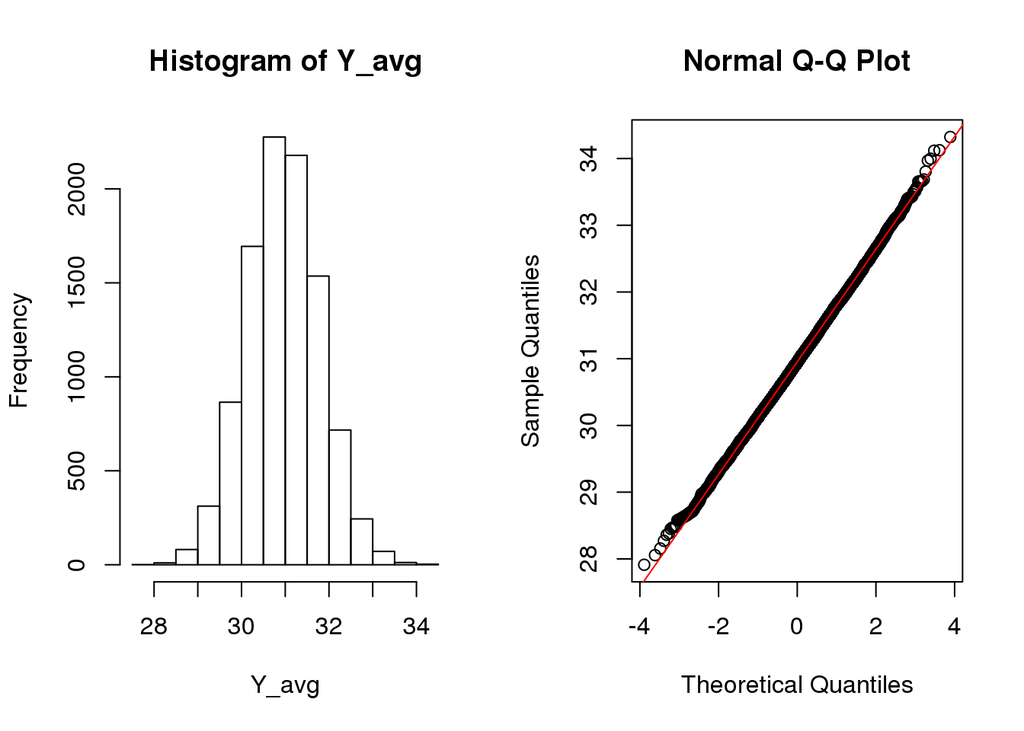

```r
y <- dat$Bodyweight[dat$Diet == "chow" & dat$Sex == "M"]
#sampmean <- function(sp_size, pop){mean(sample(pop, sp_size))}
sampfm <- function(rp_num, sp_size, pop){
  set.seed(1)
  replicate(rp_num, mean(sample(pop, sp_size)))
  #replicate(rp_num, sampmean(sp_size, pop))
}
Y_avg <- sampfm(10000, 25, y)
par(mfrow = c(1, 2))
hist(Y_avg)
qqnorm(Y_avg);qqline(Y_avg, col=2)
```

```r
round(mean(Y_avg), 4)
```

```
## [1] 30.9558
```

2.j Ans: 0.8368

```r
round(popsd(Y_avg), 4)
```

```
## [1] 0.8368
```

2.k Ans: D)popsd(y)/sqrt(25)

```r
round(popsd(y)/sqrt(25), 4)
```

```
## [1] 0.8841
```

2.l Ans: 9.64%

```r
sampfsd <- function(rp_num, sp_size, pop){
  set.seed(1)
  replicate(rp_num, sd(sample(pop, sp_size)))
}
Y_sd <- sampfsd(10000, 25, y)
round(mean(Y_sd < 3.5), 4)
```

```
## [1] 0.0964
```

#### Question 3:

3.a Ans: 4.24%

```r
ns <- 100; Nrp <- 10000
rolldice <- function(rp_num, sp_size){
  set.seed(1)
  replicate(rp_num, sample(c(1:6), sp_size, replace = TRUE))
}
X <- rolldice(Nrp, ns)
p <- 1/6;
clt_m <- p; clt_sd <- sqrt(p*(1-p)/ns)
Z <- (colMeans(X == 6) - clt_m) / clt_sd
mean(abs(Z) > 2) # CTL says the result approximate 1 - (pnorm(2) - pnorm(-2))
```

```
## [1] 0.0424
```

```r
##Another version for this experiment
#n <- 100; N <- 100000; p <- 1/6
#X <- rbinom(N, n, p)
#Z <- (X/n - p) / sqrt(p*(1-p)/n)
#mean(abs(Z) > 2)
```

3.b Ans: B) p=0.5 and n=30

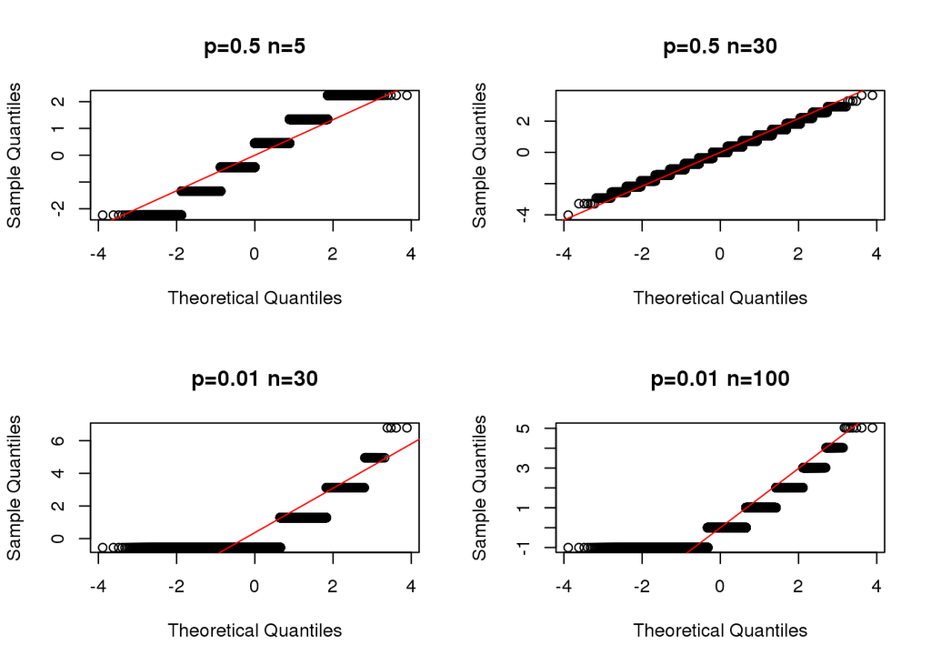

```r
#qqnorm(Z); qqline(Z, col = 2)
flexrolldice <- function(N, n, r){
  set.seed(1)
  replicate(N, sample(c(1:r), n, replace = TRUE) == 1)
}
N <- 10000
pp <- c(0.5, 0.5, 0.01, 0.01); nn <- c(5, 30, 30, 100)
par(mfrow = c(2, 2))
for(i in c(1:4)){
  X <- flexrolldice(N, nn[i], 1/pp[i])
  Z <- (colMeans(X) - pp[i]) / sqrt(pp[i]*(1-pp[i])/nn[i])
  title <- paste0("p=",pp[i]," n=",nn[i])
  qqnorm(Z, main = title); qqline(Z, col = 2)
}
```

```r
##Another version for this experiment
#N <- 10000
#pp <- c(0.5, 0.5, 0.01, 0.01); nn <- c(5, 30, 30, 100)
#par(mfrow = c(2, 2))
#for(i in c(1:4)){
#  X <- rbinom(N, nn[i], pp[i])
#  Z <- (X/nn[i] - pp[i]) / sqrt(pp[i]*(1-pp[i])/nn[i])
#  title <- paste0("p=",pp[i]," n=",nn[i])
#  qqnorm(Z, main = title); qqline(Z, col = 2)
#}
```

#### Question 4:

```r
url <- "http://ghuang.stat.nctu.edu.tw/course/statmethods16/files/data/babies.txt"
filename <- basename(url)
download.file(url, destfile=filename)
babies <- read.table("babies.txt", header=TRUE)

require(dplyr)
bwt.nonsmoke <- filter(babies, smoke == 0) %>% select(bwt) %>% unlist()
bwt.smoke <- filter(babies, smoke == 1) %>% select(bwt) %>% unlist()

require(rafalib)
mean(bwt.nonsmoke) - mean(bwt.smoke)
```

```
## [1] 8.937666
```

```r
popsd(bwt.nonsmoke)
```

```
## [1] 17.38696
```

```r
popsd(bwt.smoke)
```

```
## [1] 18.08024
```

4.a Ans: 2.1209

```r
N <- 25
set.seed(1)
dat.ns <- sample(bwt.nonsmoke, N)
dat.s <- sample(bwt.smoke, N)
tval <- (mean(dat.ns) - mean(dat.s)) / sqrt(var(dat.ns)/N + var(dat.s)/N)
round(tval, 4)
```

```
## [1] 2.1209
```

```r
#p_val <- 1-(pt(abs(tval), df = 2*(N-1)) - pt(-abs(tval), 2*(N-1)))
```

4.b Ans: D)2*pnorm(-abs(tval))

```r
2*pnorm(-abs(tval))
```

```
## [1] 0.03392985
```

4.c Ans: 12.0478

```r
round(qnorm(0.995)*sqrt(var(dat.ns)/N + var(dat.s)/N), 4)
```

```
## [1] 12.0478
```

4.d Ans: 12.5453

```r
round(qt(0.995, df = 2*(N-1))*sqrt(var(dat.ns)/N + var(dat.s)/N), 4)
```

```
## [1] 12.5453
```

4.e Ans: C)N and thus the degrees of freedom is large enough to make the normal and t distributions very similar.

4.f Ans: 0.1049

```r
N <- 5
set.seed(1)
dat.ns <- sample(bwt.nonsmoke, N)
dat.s <- sample(bwt.smoke, N)
tval <- (mean(dat.ns) - mean(dat.s)) / sqrt(var(dat.ns)/N + var(dat.s)/N)
p_val <- 1-(pt(abs(tval), df = 2*(N-1)) - pt(-abs(tval), 2*(N-1)))
round(p_val, 4)
```

```
## [1] 0.1049
```

4.g Ans: 9.84%

```r
N <- 10000; n <- 5
bwt.reject <- function(n, alpha = 0.05){
  X.ns <- sample(bwt.nonsmoke, n)
  X.s <- sample(bwt.smoke, n)
  p_val <- t.test(X.ns, X.s)$p.value
  return(p_val < alpha)
}
a <- 0.05
bwt.sampling_rej <- function(N, n, a){
  set.seed(1)
  replicate(N, bwt.reject(n, alpha = a))
}
X <- bwt.sampling_rej(N, n, a)
round(mean(X), 4)
```

```
## [1] 0.0984
```

4.h Ans: when alpha = 0.05, n = 60, the power, 78.78%, is about 80%.

```r
nn <- c(30, 60, 90, 120)
for(i in c(1:4)){
  X <- bwt.sampling_rej(N, nn[i], a)
  cat(paste0("when n = ",nn[i],",\t power = ", mean(X)),"\n")
}
```

```
## when n = 30,  power = 0.4783
## when n = 60,  power = 0.7878
## when n = 90,  power = 0.9338
## when n = 120,     power = 0.9852
```

```r
cat(paste0("at alpha = ",a,"\n"))
```

```
## at alpha = 0.05
```

4.i Ans: when alpha = 0.01, n = 90, the power, 79.69%, is about 80%.

```r
a <- 0.01
for(i in c(1:4)){
  X <- bwt.sampling_rej(N, nn[i], a)
  cat(paste0("when n = ",nn[i],",\t power = ", mean(X)),"\n")
}
```

```
## when n = 30,  power = 0.2512
## when n = 60,  power = 0.56
## when n = 90,  power = 0.7969
## when n = 120,     power = 0.9233
```

```r
cat(paste0("at alpha = ",a,"\n"))
```

```
## at alpha = 0.01
```